# Unit 3 Project

Kyle Weber

Due: Tuesday, November 18, 2025

## Front Matter

```r
#Load libraries
library(ggplot2)
library(dplyr)
library(tidyr)
library(readr)
library(caret)
library(rpart)
library(pROC)
library(FNN)
library(rpart)
library(rattle)
library(glmnet)
library(rpart.plot)
COD <- read_csv("C:/Users/3kw10/Downloads/STA508/datasets/STAT508_CODGamesP2.csv")
colSums(is.na(COD))
```

```
##             Level       FullPartial   PlayerTeamScore OpponentTeamScore
##                 0                 0                 0                 0
##      Eliminations            Deaths             Score            Damage
##                 0                 0                 0                 0
##           TotalXP            XPType              Mode              Game
##                 0                 0                 0                 0
```

## Task 1 EDA and Wrangling before Modeling

After restricting the data set to only contain games where the player completed a full match, a new binary variable called Outcome was created. This variable indicates if the player either won (1) or lost (0) the match. This variable was created using PlayerTeamScore and OpponentTeamScore. If PlayerTeamScore was greater than OpponentTeamScore then it was determined to be a win, while the opposite would be labeled a loss. If the scores were equal, essentially a tie, the match would be removed as the goal is to find out if the game was a binary win or loss.

```r
# keep only full matches
cod_full <- subset(COD, FullPartial == "Full")

# create binary outcome variable
cod_full$Outcome <- ifelse(cod_full$PlayerTeamScore > cod_full$OpponentTeamScore, 1,
                       ifelse(cod_full$PlayerTeamScore < cod_full$OpponentTeamScore, 0, NA))

# remove ties
cod_full <- subset(cod_full, !is.na(Outcome))
```

Summary statistics showed that the total number of matches was 489, with 274 (56%) of them being wins, while there were 215 losses (44%). This is visually confirmed by the bar chart. Overall, the data set is relatively balanced with the player winning slightly more than they lost.

```r
# check count
str(cod_full$Outcome)
```

```
##  num [1:489] 1 0 1 0 0 0 0 1 0 0 ...
```

```r
# frequency table
table(cod_full$Outcome)
```

```
##
##   0   1
## 215 274
```

```r
# proportion table
prop.table(table(cod_full$Outcome))
```

```
##
##         0         1
## 0.4396728 0.5603272
```

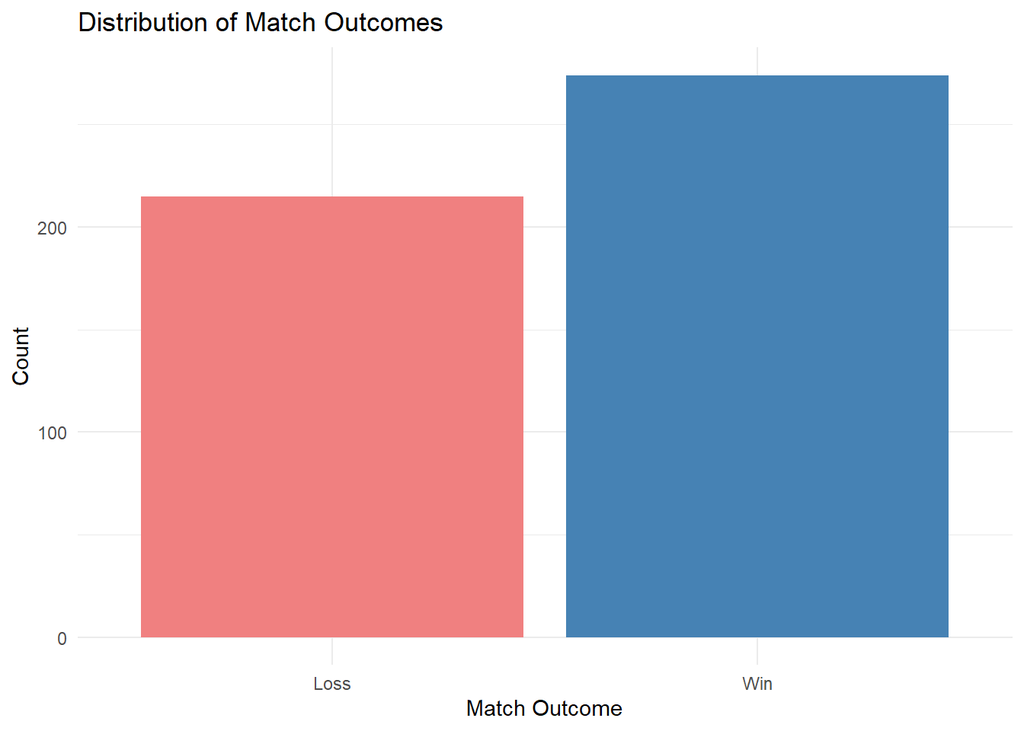

```r
# bar chart
ggplot(cod_full, mapping = aes(x = factor(Outcome, labels = c("Loss", "Win")))) +
  geom_bar(fill = c("lightcoral", "steelblue")) +
  labs(title = "Distribution of Match Outcomes",
       x = "Match Outcome",
       y = "Count") +
  theme_minimal()
```

## Task 2 Classification Models

#### Data Split:

Before starting to build any of the models some data preparation is performed by splitting the data into a training set with 80% of the observations and a validation set with the remaining 20% of observations.

```r
# Data split
set.seed(123)
trainInd <- sample(1:nrow(cod_full), floor(0.8 * nrow(cod_full)), replace = FALSE)
set.seed(NULL)

# Create training and validation sets
train <- cod_full[trainInd, ]
validation <- cod_full[-trainInd, ]
```

#### Logistic Regression

To decide which variables would be included in the model, a forwards and backwards stepwise regression was applied on the full model with the exception of PlayerTeamScore and OpponentTeamScore as they were used in the variable creation of Outcome. The stepwise selection used AIC to refine the model and choose the variables that were both parsimonious and had strong predictive power. The variables that were retained are Eliminations, Deaths, Score, Damage, TotalXP, Mode, and XPType. In total seven variables were kept while Level and Game were dropped from the model.

```r
# full logistic regression model excluding team scores
full_mod <- glm(Outcome ~ Eliminations + Deaths + Score + Damage + TotalXP + Mode + Game + XPType + Level,
                family = binomial, data = train)

# forwards and back stepwise selection
step_mod <- step(full_mod, direction = "both")
```

```
## Start:  AIC=479.26
## Outcome ~ Eliminations + Deaths + Score + Damage + TotalXP +
##     Mode + Game + XPType + Level
##
##                Df Deviance    AIC
## - Level        24   434.59 456.59
## <none>              409.26 479.26
## - Game          3   415.58 479.58
## - Mode          1   413.78 481.78
## - Damage        1   419.95 487.95
## - Score         1   420.62 488.62
## - Eliminations  1   423.39 491.39
## - XPType        1   424.22 492.22
## - TotalXP       1   434.08 502.08
## - Deaths        1   444.53 512.53
##
## Step:  AIC=456.59
## Outcome ~ Eliminations + Deaths + Score + Damage + TotalXP +
##     Mode + Game + XPType
##
##                Df Deviance    AIC
## - Game          3   439.67 455.67
## <none>              434.59 456.59
## - Mode          1   438.63 458.63
## - Damage        1   443.94 463.94
## - Score         1   446.01 466.01
## - XPType        1   446.48 466.48
## - Eliminations  1   451.48 471.48
## - TotalXP       1   457.98 477.98
## + Level        24   409.26 479.26
## - Deaths        1   474.00 494.00
##
## Step:  AIC=455.67
## Outcome ~ Eliminations + Deaths + Score + Damage + TotalXP +
##     Mode + XPType
##
##                Df Deviance    AIC
## <none>              439.67 455.67
## + Game          3   434.59 456.59
## - Mode          1   443.29 457.29
## - Damage        1   448.24 462.24
## - Score         1   450.73 464.73
## - XPType        1   452.43 466.43
## - Eliminations  1   457.50 471.50
## - TotalXP       1   464.92 478.92
## + Level        24   415.58 479.58
## - Deaths        1   487.89 501.89
```

```r
# summary
summary(step_mod)
```

```
##
## Call:
## glm(formula = Outcome ~ Eliminations + Deaths + Score + Damage +
##     TotalXP + Mode + XPType, family = binomial, data = train)
##
## Coefficients:
##                 Estimate Std. Error z value Pr(>|z|)
## (Intercept)    1.177e+00  7.281e-01   1.617 0.105973
## Eliminations   1.762e-01  4.311e-02   4.087 4.37e-05 ***
## Deaths        -2.043e-01  3.259e-02  -6.268 3.65e-10 ***
## Score         -5.611e-04  1.708e-04  -3.286 0.001016 **
## Damage        -8.841e-04  3.062e-04  -2.887 0.003883 **
## TotalXP        1.720e-04  3.733e-05   4.609 4.04e-06 ***
## ModeHardCore  -1.304e+00  6.892e-01  -1.892 0.058507 .
## XPTypeRegular  1.240e+00  3.568e-01   3.475 0.000511 ***
## ---
## Signif. codes:  0 '***' 0.001 '**' 0.01 '*' 0.05 '.' 0.1 ' ' 1
##
## (Dispersion parameter for binomial family taken to be 1)
##
##     Null deviance: 536.38  on 390  degrees of freedom
## Residual deviance: 439.67  on 383  degrees of freedom
## AIC: 455.67
##
## Number of Fisher Scoring iterations: 4
```

The summary statistics for model 1 indicates that higher Eliminations and TotalXP are associated with increased odds of winning, while the variables Deaths, Score, and Damage slightly reduce the odds of the player winning. Additionally, the player had lower odds of winning in the mode Hardcore than in Core (OR = 0.27), while Regular XP matches more than tripled the odds of winning compared to DoubleXP (OR = 3.46). This initial look at the variables provides a good base for understanding the relationships that each model has on Outcome.

```r
model1 <- glm(Outcome ~ Eliminations + Deaths + Score + Damage + TotalXP + Mode + XPType,
              family = binomial,
              data = train)

summary(model1)
```

```
##
## Call:
## glm(formula = Outcome ~ Eliminations + Deaths + Score + Damage +
##     TotalXP + Mode + XPType, family = binomial, data = train)
##
## Coefficients:
##                 Estimate Std. Error z value Pr(>|z|)
## (Intercept)    1.177e+00  7.281e-01   1.617 0.105973
## Eliminations   1.762e-01  4.311e-02   4.087 4.37e-05 ***
## Deaths        -2.043e-01  3.259e-02  -6.268 3.65e-10 ***
## Score         -5.611e-04  1.708e-04  -3.286 0.001016 **
## Damage        -8.841e-04  3.062e-04  -2.887 0.003883 **
## TotalXP        1.720e-04  3.733e-05   4.609 4.04e-06 ***
## ModeHardCore  -1.304e+00  6.892e-01  -1.892 0.058507 .
## XPTypeRegular  1.240e+00  3.568e-01   3.475 0.000511 ***
## ---
## Signif. codes:  0 '***' 0.001 '**' 0.01 '*' 0.05 '.' 0.1 ' ' 1
##
## (Dispersion parameter for binomial family taken to be 1)
##
##     Null deviance: 536.38  on 390  degrees of freedom
## Residual deviance: 439.67  on 383  degrees of freedom
## AIC: 455.67
##
## Number of Fisher Scoring iterations: 4
```

```r
exp(coef(model1))
```

```
##   (Intercept)  Eliminations        Deaths         Score        Damage
##     3.2446461     1.1926704     0.8152410     0.9994390     0.9991163
##       TotalXP  ModeHardCore XPTypeRegular
##     1.0001721     0.2714755     3.4553675
```

The logistic regression performance was evaluated on the validation set using a 0.5 classification threshold. The confusion matrix showed an overall accuracy of 63%, with a recall and precision of about 67%. An ROC curve was also generated which gave and AUC value of 0.725, indicating the the model is able to generalize to new data reasonably well while still being very interpretable.

```r
logit_Prob <- predict(model1, newdata = validation,
        type = "response")


# pred + threshold 0.5
logit_pred <- ifelse(logit_Prob > 0.5, 1, 0)

# build confusion table
CM <- table(Predicted = logit_pred, Actual = validation$Outcome)
CM
```

```
##          Actual
## Predicted  0  1
##         0 25 18
##         1 18 37
```

```r
TP <- CM["1", "1"]
FP <- CM["1", "0"]
TN <- CM["0", "0"]
FN <- CM["0", "1"]

# metrics
recall      <- TP / (TP + FN)
precision   <- TP / (TP + FP)
specificity <- TN / (TN + FP)
accuracy    <- (TP + TN) / sum(CM)

# Print results
recall
```

```
## [1] 0.6727273
```

```r
precision
```

```
## [1] 0.6727273
```

```r
specificity
```

```
## [1] 0.5813953
```

```r
accuracy
```

```
## [1] 0.6326531
```

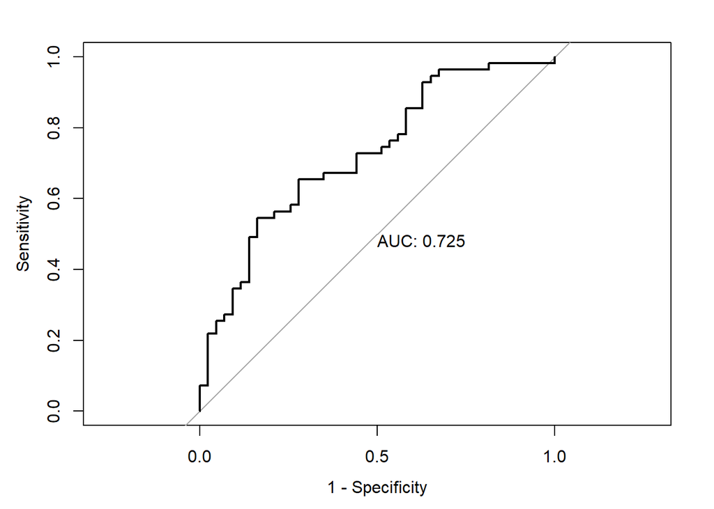

```r
#Create the ROC curve
rocCurve <- roc(response = validation$Outcome,
                predictor = logit_Prob,
                plot = TRUE,
                print.auc = TRUE,
                legacy.axes = TRUE)
```

```r
as.numeric(rocCurve$auc)
```

```
## [1] 0.7247357
```

#### k-Nearest Neighbors

The k-nearest neighbors model was started by selecting all numeric and categorical predictors other than PlayerTeamScore and OpponentTeamScore. The categorical variables (Mode, XPType, Game, and Level) were converted into dummy variables so they could be included in the model in addition to all predictors being standardized to ensure equal weighting. Again the data was split into an 80% training set and 20% validation set.

```r
# select predictors, numeric + categorical
predictors <- cod_full %>%
  select(Eliminations, Deaths, Score, Damage, TotalXP, Mode, XPType, Game, Level)

# turn categorical variables into dummy variables
predictors_dummy <- model.matrix(~ ., data = predictors)[, -1]

# scale all predictors
cod_scaled <- as.data.frame(scale(predictors_dummy))

# add outcome back
cod_scaled$Outcome <- cod_full$Outcome

# data split
set.seed(123)
trainInd <- sample(1:nrow(cod_scaled), floor(0.8*nrow(cod_scaled)), replace = FALSE)
set.seed(NULL)

train <- cod_scaled[trainInd, ]
validation <- cod_scaled[-trainInd, ]
```

A loop was used to find the optimal value of k, which turned out to be 24, yielding an accuracy of 0.622. The optimal K and its value can be visually confirmed by the graph below.

```r
xvars <- setdiff(names(train), "Outcome")

maxK <- 25
accVec <- rep(NA, maxK)

for(i in 1:maxK){
  knnResTemp <- knn(train = train[, xvars, drop = FALSE],
                    test = validation[, xvars, drop = FALSE],
                    cl = train$Outcome,
                    k = i)

  validation <- validation %>%
    mutate(predOutcome = factor(knnResTemp, levels = levels(factor(train$Outcome))))

  accVec[i] <- mean(validation$Outcome == validation$predOutcome)
}

# accuracy
accVec
```

```
##  [1] 0.4489796 0.3979592 0.4387755 0.4795918 0.5102041 0.5408163 0.5714286
##  [8] 0.5918367 0.5714286 0.5714286 0.5612245 0.5306122 0.5612245 0.5408163
## [15] 0.5816327 0.6020408 0.6122449 0.6122449 0.5510204 0.5510204 0.5408163
## [22] 0.5918367 0.5816327 0.6224490 0.6020408
```

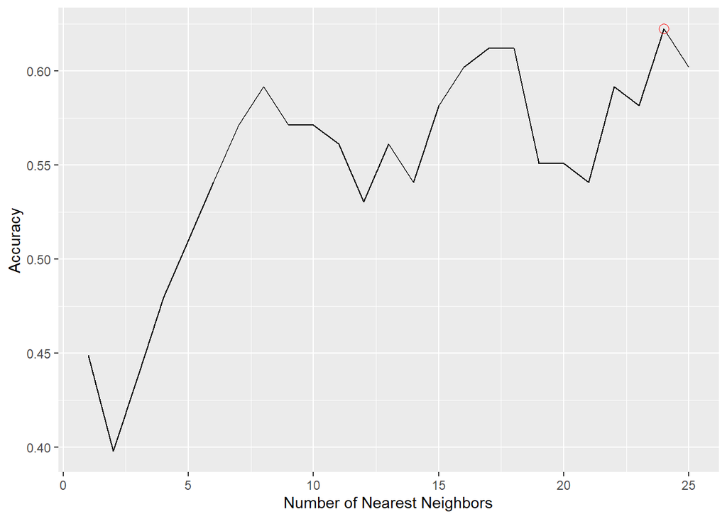

```r
# plot
tempDF <- data.frame(k = 1:maxK, Accuracy = accVec)

ggplot(tempDF, aes(x = k, y = Accuracy)) +
  geom_line() +
  geom_point(data = tempDF[which.max(accVec), ], color = "red", shape = 1, size = 3) +
  labs(x = "Number of Nearest Neighbors", y = "Accuracy")
```

```r
# optimal k
which.max(accVec)
```

```
## [1] 24
```

```r
accVec[which.max(accVec)]
```

```
## [1] 0.622449
```

```r
set.seed(123)
# fit kNN at optimal k
optK <- 24
knn_pred <- knn(train = train[, xvars, drop = FALSE],
                test = validation[, xvars, drop = FALSE],
                cl = train$Outcome,
                k = optK,
                prob = TRUE)

# confusion matrix
CM_knn <- confusionMatrix(knn_pred, factor(validation$Outcome, levels = c(0,1)), positive = "1")


# metrics
accuracy_knn <- CM_knn$overall["Accuracy"]
recall_knn <- CM_knn$byClass["Sensitivity"]
precision_knn <- CM_knn$byClass["Precision"]
specificity_knn <- CM_knn$byClass["Specificity"]

accuracy_knn
```

```
## Accuracy
## 0.622449
```

```r
recall_knn
```

```
## Sensitivity
##   0.8181818
```

```r
precision_knn
```

```
## Precision
##     0.625
```

```r
specificity_knn
```

```
## Specificity
##    0.372093
```

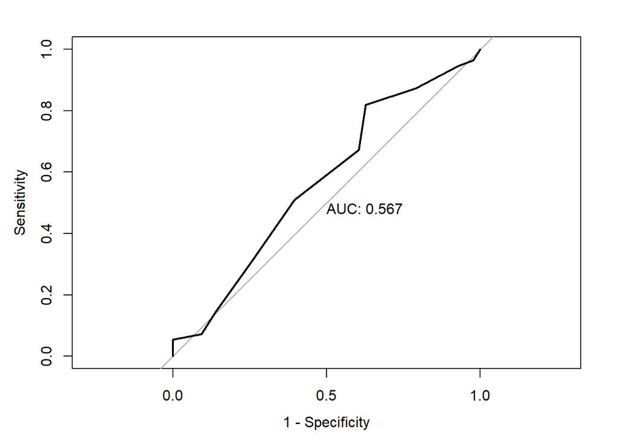

```r
knn_probs <- attr(knn_pred, "prob")
knn_probs <- ifelse(knn_pred == "1", knn_probs, 1 - knn_probs)

set.seed(NULL)
#Create the ROC curve
rocCurve <- roc(response = validation$Outcome,
                predictor = knn_probs,
                plot = TRUE,
                print.auc = TRUE,
                legacy.axes = TRUE)
```

```r
as.numeric(rocCurve$auc)
```

```
## [1] 0.5672304
```

#### Classification Tree

To start the classification tree, a full tree was grown using all predictors other than PlayerTeamScore and OpponentTeamScore with an initial complexity parameter of 0.003 and 10 fold cross validation. Using the one standard error metric to determine the optimal value of cp, 0.0407 was determined to be the best fit and was subsequently used to prune the tree.

```r
predictors <- cod_full %>%
  select(Level, Eliminations, Deaths, Score, Damage, TotalXP, XPType, Mode, Game)

# dummy encode categorical variables
predictors_dummy <- model.matrix(~ ., data = predictors)[, -1]

# add Outcome back
cod_tree <- as.data.frame(predictors_dummy)
cod_tree$Outcome <- cod_full$Outcome

# new train/validation split
set.seed(123)
trainInd2 <- sample(1:nrow(cod_tree), floor(0.8*nrow(cod_tree)), replace = FALSE)
set.seed(NULL)

train2 <- cod_tree[trainInd2, ]
validation2 <- cod_tree[-trainInd2, ]



set.seed(123)
fullTree <- rpart(Outcome ~ .,
                  data = train2,
                  method = "class",
                  cp = 0.003,
                  xval = 10)
set.seed(NULL)

# cross-validation results
fullTree$cptable
```

```
##            CP nsplit rel error    xerror       xstd
## 1 0.250000000      0 1.0000000 1.0000000 0.05706495
## 2 0.040697674      1 0.7500000 0.7965116 0.05484794
## 3 0.011627907      4 0.6279070 0.8023256 0.05493928
## 4 0.005813953     12 0.5348837 0.8662791 0.05583210
## 5 0.003875969     13 0.5290698 0.8779070 0.05597283
## 6 0.003000000     16 0.5174419 0.8779070 0.05597283
```

[figure not shown]

```r
# visualize full tree
fancyRpartPlot(fullTree, cex = 0.4)
```

```r
# row with smallest CV error
cpRow <- which.min(fullTree$cptable[, "xerror"])

# calculate threshold = min(xerror) + xstd
target <- fullTree$cptable[cpRow, "xerror"] + fullTree$cptable[cpRow, "xstd"]

# find first cp where xerror < threshold
cpRow1se <- which(fullTree$cptable[, "xerror"] < target)[1]

cpChoice1se <- fullTree$cptable[cpRow1se, "CP"]

# display chosen cp
cpChoice1se
```

```
## [1] 0.04069767
```

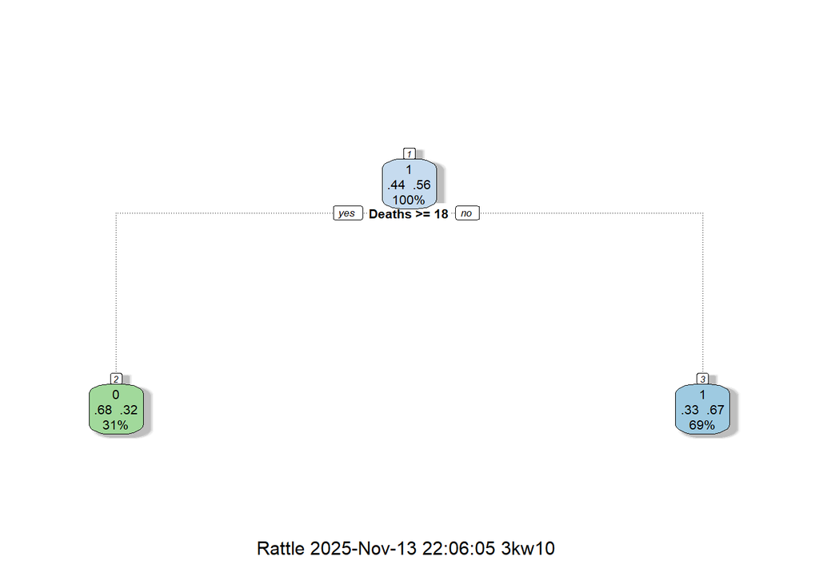

```r
# prune using cp from 1-SE rule
prunedTree <- prune(fullTree, cp = cpChoice1se)

# visualize pruned tree
fancyRpartPlot(prunedTree, cex = 0.65)
```

The pruned tree allowed for predictions to be run on the validation set, which achieved an overall accuracy of 57.1%. The confusion matrix also showed that the model was better at identifying wins than losses, similar to the previous kNN model. The sensitivity was 0.75 whereas the specificity was 0.35, so the model was able to correctly predict 41 out of 55 wins compared to 15 out of 43 losses. As with all other models done so far an AUC value was found which turned out to be 0.547 showing that its discriminative power is very limited. Additionally, the ranked variable importance showed that Deaths was overwhelmingly dominant with a score of 19.82 with Game following behind in second place with scores of 3.93 (TDM) and 2.95 (HardPoint).

```r
# predict on validation data
prunedPred <- predict(prunedTree, newdata = validation2, type = "class")

# confusion matrix
Cmat <- table(Predicted = prunedPred, Actual = validation2$Outcome)
Cmat
```

```
##          Actual
## Predicted  0  1
##         0 15 14
##         1 28 41
```

```r
# accuracy
accuracy_tree <- mean(prunedPred == validation2$Outcome)
accuracy_tree
```

```
## [1] 0.5714286
```

```r
confusionMatrix(prunedPred, factor(validation2$Outcome, levels = c(0,1)), positive = "1")
```

```
## Confusion Matrix and Statistics
##
##           Reference
## Prediction  0  1
##          0 15 14
##          1 28 41
##
##                Accuracy : 0.5714
##                  95% CI : (0.4675, 0.671)
##     No Information Rate : 0.5612
##     P-Value [Acc > NIR] : 0.46114
##
##                   Kappa : 0.0978
##
##  Mcnemar's Test P-Value : 0.04486
##
##             Sensitivity : 0.7455
##             Specificity : 0.3488
##          Pos Pred Value : 0.5942
##          Neg Pred Value : 0.5172
##              Prevalence : 0.5612
##          Detection Rate : 0.4184
##    Detection Prevalence : 0.7041
##       Balanced Accuracy : 0.5471
##
##        'Positive' Class : 1
##
```

```r
# variable importance from pruned tree
importance <- prunedTree$variable.importance
importance
```

```
##        Deaths       GameTDM GameHardpoint  Eliminations        Damage
##    19.8156877     3.9303843     2.9477883     1.1463621     0.9825961
##  LevelEchelon
##     0.3275320
```

```r
# top 3 variables
head(sort(importance, decreasing = TRUE), 3)
```

```
##        Deaths       GameTDM GameHardpoint
##     19.815688      3.930384      2.947788
```

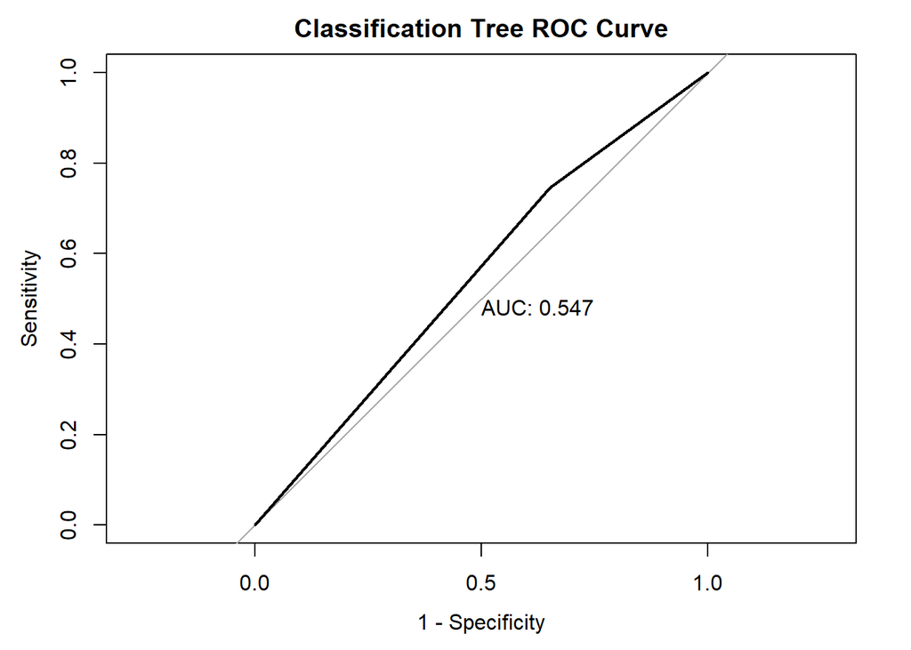

```r
# predict probabilities for validation set
tree_probs <- predict(prunedTree, newdata = validation2, type = "prob")[, "1"]

# ROC curve
roc_tree <- roc(response = validation2$Outcome,
                predictor = tree_probs,
                plot = TRUE,
                print.auc = TRUE,
                legacy.axes = TRUE,
                main = "Classification Tree ROC Curve")
```

```r
# numeric AUC value
as.numeric(roc_tree$auc)
```

```
## [1] 0.5471459
```

## Task 3 Extending an Unit 2 Topic

#### References

In order to answer the question, I used guides from these sources as well as many other more specific sources when needed. I tried to combine the information of how to create a LASSO logistic regression with the code, format, and information from both the logistic regression and lasso modules / homeworks we did in class.

https://www.sthda.com/english/articles/36-classification-methods-essentials/149-penalized-logistic-regression-essentials-in-r-ridge-lasso-and-elastic-net/

https://www.statology.org/lasso-regression-in-r/

#### Creating and Analyzing the Model

To turn the logistic regression from task 2 into a LASSO logistic regression, an 80-20 split was done with the following predictors included in the model, Eliminations, Deaths, Score, Damage, TotalXP, Mode, Game, and XPType. Here, Level was dropped from the model given its previous insignificance along with numerous errors generated from mismatched factor levels across the training and validation sets. Since Level has previously been insignificant and conceptually should not have any impact of the players wins or losses, this should improve the codes clarity without any substantial impact. Next, the categorical variables were transformed into dummy variables and a 10 fold cross validation was done to determine the optimal value of lambda which was 0.003.

This lambda value was fit into the final model to generate the end results, showing that the most important retained positive predictors were, Eliminations, TotalXP, and XPTypeRegular, while the negative key predictors were, GameKill Confirmed, Deaths, and ModeHardCore. While many of the predictors were shrunk close to zero, the only predictor to be completely shrunk was GameTDM. The overall Accuracy of the model was 0.633, the sensitivity was 0.673, the specificity was 0.581, and the AUC value equaled 0.714. The model appears to do relatively well at predicting wins and losses with it being slightly better at predicting wins than losses and with an AUC score of 0.714 its descriminative ability is rather high.

Overall, these results are all identical to the regular Logistic Regression that was created in task 2 with the exception of this model having a slightly lower AUC score. These similar results could be due to the small lambda value that did not meaningfully shrink the coefficients to zero with all but 1 still remaining. Since both the LASSO and the stepwise functions chose very similar variables to keep in the model, it is not very surprising the results are so similar.

```r
# Data split
set.seed(123)
trainInd3 <- sample(1:nrow(cod_full), floor(0.8 * nrow(cod_full)), replace = FALSE)
set.seed(NULL)

# Create training and validation sets
train3 <- cod_full[trainInd3, ]
validation3 <- cod_full[-trainInd3, ]

# build  training model
X <- model.matrix(Outcome ~ Eliminations + Deaths + Score + Damage + TotalXP + Mode + Game + XPType,
                  data = train3)[, -1]
Y <- train3$Outcome

# build validation model
X_val <- model.matrix(Outcome ~ Eliminations + Deaths + Score + Damage + TotalXP + Mode + Game + XPType,
                      data = validation3)[, -1]

Y_val <- validation3$Outcome

# fit LASSO logistic regression with cv
set.seed(123)
lassoCV <- cv.glmnet(x = X, y = Y,
                     family = "binomial",
                     alpha = 1,
                     nfolds = 10)
set.seed(NULL)

# optimal min lambda
lambda_min  <- lassoCV$lambda.min
print(lambda_min)
```

```
## [1] 0.003048505
```

```r
# create final model for lambda min
set.seed(123)
lasso_model <- glmnet(x = X, y = Y,
                      family = "binomial",
                      alpha = 1,
                      lambda = lambda_min)

set.seed(NULL)

#store the coefficients
coefLamMin <- predict(lassoCV, s = lassoCV$lambda.min, type = "coefficients")

# create a data frame for comparing the coefficients
tempdf <-
  data.frame(Variable = row.names(coefLamMin),
             lamMin = as.numeric(coefLamMin))

tempdf
```

```
##              Variable        lamMin
## 1         (Intercept)  1.0695304570
## 2        Eliminations  0.1451530138
## 3              Deaths -0.1928253756
## 4               Score -0.0004869018
## 5              Damage -0.0006165489
## 6             TotalXP  0.0001491165
## 7        ModeHardCore -0.7691609702
## 8       GameHardpoint  0.0158002528
## 9  GameKill Confirmed -1.9527464887
## 10            GameTDM  0.0000000000
## 11      XPTypeRegular  1.0251769117
```

```r
# predict probabilities on validation set
prob_lasso <- predict(lasso_model, newx = X_val, type = "response")

# threshold 0.5
pred_lasso <- ifelse(prob_lasso > 0.5, 1, 0)


# confusion matrix and metrics
CM_lasso <- confusionMatrix(factor(pred_lasso, levels = c(0,1)),
                            factor(Y_val, levels = c(0,1)), positive = "1")

accuracy_lasso   <- CM_lasso$overall["Accuracy"]
sensitivity_lasso <- CM_lasso$byClass["Sensitivity"]
specificity_lasso <- CM_lasso$byClass["Specificity"]
precision_lasso   <- CM_lasso$byClass["Precision"]

# results
accuracy_lasso
```

```
##  Accuracy
## 0.6326531
```

```r
sensitivity_lasso
```

```
## Sensitivity
##   0.6727273
```

```r
specificity_lasso
```

```
## Specificity
##   0.5813953
```

```r
precision_lasso
```

```
## Precision
## 0.6727273
```

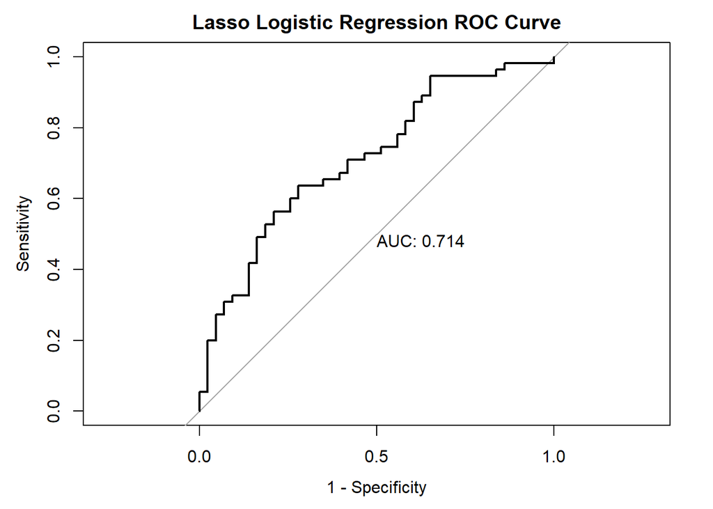

```r
# ROC curve
roc_lasso <- roc(response = validation3$Outcome,
                predictor = as.vector(prob_lasso),
                plot = TRUE,
                print.auc = TRUE,
                legacy.axes = TRUE,
                main = "Lasso Logistic Regression ROC Curve")
```

```r
# numeric AUC value
as.numeric(roc_lasso$auc)
```

```
## [1] 0.7137421
```